# Reproducible Research: Peer Assessment 1

## Loading and preprocessing the data

```r
#Download the data
    filename <- "Coursera_RR_Assignment1.zip"

    # Checking if archieve already exists.
    if (!file.exists(filename)){
        fileURL <- "https://d396qusza40orc.cloudfront.net/repdata%2Fdata%2Factivity.zip"
        download.file(fileURL, filename, method="curl")
    }

    # Checking if the unzipped folder exists and unzip if it doesn't
    if (!file.exists("activity.csv")) {
        unzip(filename)
    } else {
        print("File exists")
    }
```

```
## [1] "File exists"
```

```r
    library("pacman")
    pacman::p_load(readr, dplyr, knitr, ggplot2, chron, lattice)
```

```r
    # Import the data and review it
    rawData <- read.csv("activity.csv", stringsAsFactors = FALSE)
    summary(rawData)
```

```
##      steps            date              interval
##  Min.   :  0.00   Length:17568       Min.   :   0.0
##  1st Qu.:  0.00   Class :character   1st Qu.: 588.8
##  Median :  0.00   Mode  :character   Median :1177.5
##  Mean   : 37.38                      Mean   :1177.5
##  3rd Qu.: 12.00                      3rd Qu.:1766.2
##  Max.   :806.00                      Max.   :2355.0
##  NA's   :2304
```

```r
    data <- rawData
```

## What is the mean total number of steps taken per day?

For this part of the assignment, we can ignore the missing values in the data set.

```r
    data <- na.omit(data)
```

1. Calculate the total number of steps taken per day

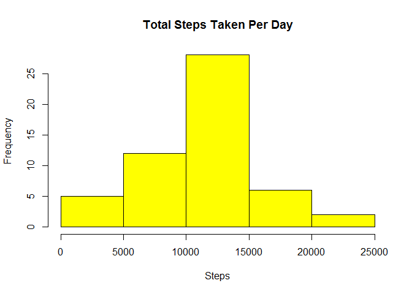

```r
    data$date <- as.Date(data$date)
    dailySteps <- data%>%
                    group_by(date) %>%
                    summarise(steps=sum(steps))
    hist(dailySteps$steps, main="Total Steps Taken Per Day", xlab = "Steps", col = "Yellow")
```

2. Calculate and report the mean and median of the total number of steps taken per day

```r
    summary <- dailySteps %>%
                summarise(meanSteps = mean(steps),
                            medianSteps = median(steps))
```

The following table presents the mean and median of the total number of steps taken per day (between 2012-10-02 and 2012-11-29.

```r
    kable(summary, format.args = list(big.mark = ","),
          format = "markdown",
          align = 'c', padding = 20,
          col.names = c("Mean Daily Steps", "Median Daily Steps"))
```

| Mean Daily Steps | Median Daily Steps |
| --- | --- |
| 10,766.19 | 10,765 |

## What is the average daily activity pattern?

1. Make a time series plot (i.e.`type = "l"`) of the 5-minute interval (x-axis) and the average number of steps taken, averaged across all days (y-axis)

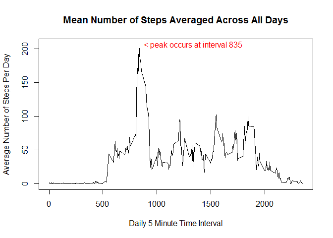

```r
    avInt <- data %>%
                group_by(interval) %>%
                summarise(meanSteps = mean(steps))

    maxSteps <- avInt[which.max(avInt$meanSteps),1]

    plot(avInt$meanSteps~avInt$interval, type = "l",
         main = "Mean Number of Steps Averaged Across All Days",
         xlab = "Daily 5 Minute Time Interval", ylab = "Average Number of Steps Per Day")
    abline(v = maxSteps, col = "lightgrey", lty = 3)
    text(x=maxSteps, y=max(avInt$meanSteps), paste("< peak occurs at interval",maxSteps), col = "red", srt = 0, pos = 4)
```

2. Which 5-minute interval, on average across all the days in the data set, contains the maximum number of steps?